# Mineria de Datos y Modelacion Predictiva - Guillermo Villarino

AndreGibu

30/6/2020

## Análisis Descriptivo de datos

En esta sección se realizará:

Análisis descriptivo del conjunto de datos. Número de observaciones, número y naturaleza de variables, datos erróneos etc. Distribuciones de variables.

Análisis de valores extremos (outliers). Decisiones

Análisis de valores perdidos. Imputaciones.

Transformaciones de variables y relaciones con las variables objetivo.

```r
# Lectura del archivo
setwd("C:/Users/andre/Documents/Mineria_de_datos/tarea/")
Radiacion2005 <- readRDS("Radiacion2005.RDS")

# Inpsección rápida
str(Radiacion2005)
```

```
## 'data.frame':    8760 obs. of  11 variables:
##  $ Fecha      : POSIXct, format: "2005-01-01 00:00:58" "2005-01-01 01:00:58" ...
##  $ TD         : num  152 154 153 153 152 ...
##  $ Radon      : num  64 74.8 56.5 61.5 54 ...
##  $ Desc.Rn    : num  58.1 66.7 68.7 67 64.6 ...
##  $ Pres       : num  954 954 954 954 953 ...
##  $ Temp       : num  3.35 2.98 2.69 2.2 1.81 ...
##  $ HR         : num  87.9 91 91.9 92.2 92.9 ...
##  $ Vviento    : num  0 0 1.08 0.36 0.24 0.66 0 0 0 2.46 ...
##  $ Luvia      : num  0 0 0 0 0 0 0 0 0 0 ...
##  $ Irrad.solar: num  NA NA 17 17.5 17.5 ...
##  $ PicoRad    : num  0 0 0 0 0 0 0 0 0 0 ...
```

```r
summary(Radiacion2005)
```

```
##      Fecha                           TD            Radon
##  Min.   :2005-01-01 00:00:58   Min.   :143.9   Min.   :  0.00
##  1st Qu.:2005-04-02 05:45:58   1st Qu.:152.0   1st Qu.:  9.00
##  Median :2005-07-02 11:30:58   Median :155.6   Median : 14.33
##  Mean   :2005-07-02 11:30:58   Mean   :155.5   Mean   : 21.72
##  3rd Qu.:2005-10-01 17:15:58   3rd Qu.:158.6   3rd Qu.: 28.67
##  Max.   :2005-12-31 23:00:58   Max.   :185.2   Max.   :148.67
##                                NA's   :1146    NA's   :318
##     Desc.Rn              Pres            Temp              HR
##  Min.   :  0.1123   Min.   :925.6   Min.   :-7.407   Min.   : 9.90
##  1st Qu.:  4.3946   1st Qu.:939.5   1st Qu.: 8.273   1st Qu.:36.32
##  Median :  8.3817   Median :942.8   Median :15.020   Median :54.23
##  Mean   : 15.6849   Mean   :943.1   Mean   :15.727   Mean   :55.08
##  3rd Qu.: 20.0167   3rd Qu.:946.5   3rd Qu.:22.793   3rd Qu.:74.08
##  Max.   :115.3333   Max.   :962.0   Max.   :41.250   Max.   :99.00
##  NA's   :1236       NA's   :329     NA's   :329      NA's   :329
##     Vviento           Luvia          Irrad.solar       PicoRad
##  Min.   : 0.000   Min.   :0.00000   Min.   :  0.0   Min.   :0.0000
##  1st Qu.: 0.180   1st Qu.:0.00000   1st Qu.:  9.0   1st Qu.:0.0000
##  Median : 2.520   Median :0.00000   Median : 19.3   Median :0.0000
##  Mean   : 3.375   Mean   :0.02767   Mean   :116.4   Mean   :0.1546
##  3rd Qu.: 5.220   3rd Qu.:0.00000   3rd Qu.:211.6   3rd Qu.:0.0000
##  Max.   :53.400   Max.   :7.20000   Max.   :570.8   Max.   :1.0000
##                                     NA's   :1213    NA's   :1146
```

Observamos que en las variables objetivos TD y PicoRad hay 1146 valores NA’s que son los que tomaremos como data para test.

La variable Temp tiene valores negativos lo que debe ser un error

La variables Lluvia tiene pocos valores ya que 1st Qu., Median y 3er Qu. son 0. Además que los valores que tiene están alejados de cero.

La variable Irrad.Solar tiene mucha diferencia entre su mediana y media lo que hace pensar que tiene valores muy altos a la derecha de la mediana.

## Visualización de datos temporales

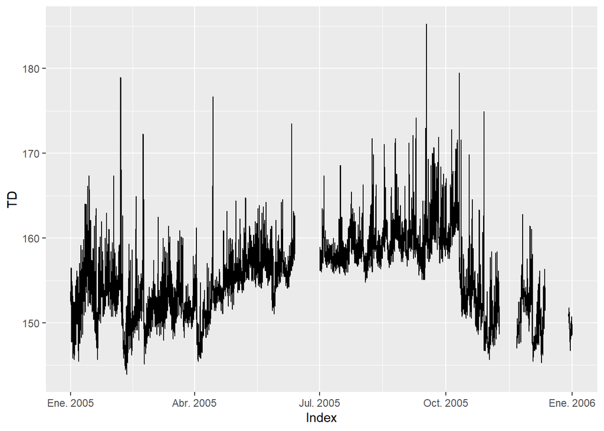

```r
# crear serie temporal periodo completo
Rad5_tmp<-xts(as.matrix(Radiacion2005[,-1]), order.by = Radiacion2005$Fecha)
# Representación de variables objetivo
autoplot(Rad5_tmp$TD)
```

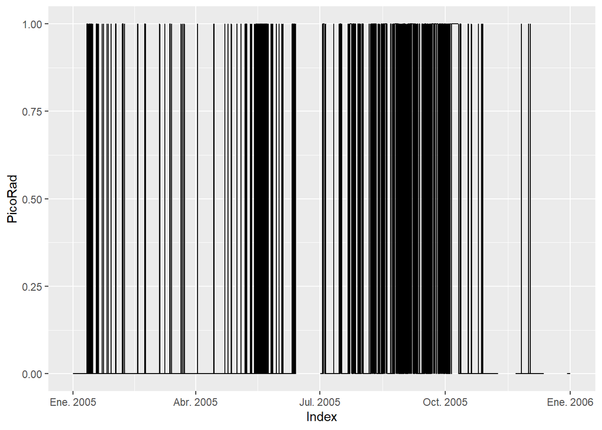

```r
autoplot(Rad5_tmp$PicoRad) # Es una variable binaria...
```

Observamos ausencia de datos en los días previos a julio, diciembre y enero 2006

#Análisis descriptivo del conjunto de datos

```r
# Cuento el número de valores diferentes para las numéricas
sapply(Filter(is.numeric, Radiacion2005),function(x) length(unique(x)))
```

```
##          TD       Radon     Desc.Rn        Pres        Temp          HR
##         170         561        4874        8168        5312        3021
##     Vviento       Luvia Irrad.solar     PicoRad
##         340          41        2613           3
```

La variable PicoRad es objetivo y no será considerada numérica.

La variables Lluvia es la que menos valores tiene pero es mayor a 10 por lo que la conservamos numérica

El la función summary ya habíamos observadr a la función Lluvia pero también a la variable Irrad.solar

```r
Radiacion2005["PicoRad"]<-lapply(
  subset(Radiacion2005, select =c(PicoRad)), factor)
```

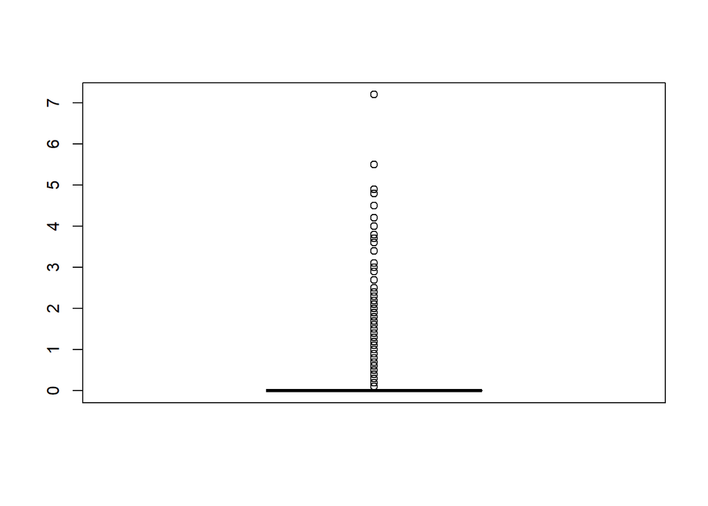

```r
# Boxplot para las variables Luvia y Irrad.solar
boxplot(Radiacion2005$Luvia)
```

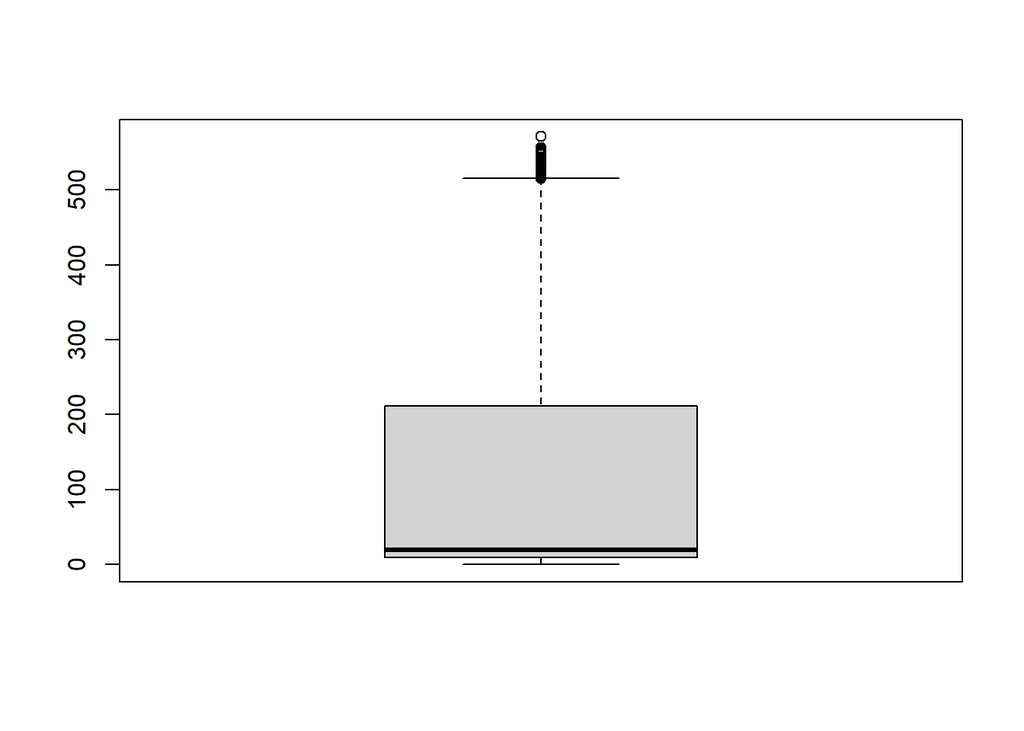

```r
boxplot(Radiacion2005$Irrad.solar)
```

La variables Luvia tiene valores concentrados en 0 y pocos valores lejos del 0, podríamo agrupar en grupos.

```r
# Preguntamos si hay missings en el archivo excluyendo data test

any(is.na(Radiacion2005[which(!is.na(Radiacion2005$TD)),]))
```

```
## [1] TRUE
```

```r
#write.csv(Radiacion2005,"Radiacion2005.csv")
```

Ya habíamos observados muchos valores nulo y no sólo en la data de test.

```r
#Indico la variableObj, el ID y las Input (los atípicos y
# los missings se gestionan sólo de las input)
varObjCont<-Radiacion2005$TD
varObjBin<-Radiacion2005$PicoRad
input<-as.data.frame(Radiacion2005[,-c(2,11)])
```

**Crea una variable categórica a partir de la variable “Luvia” que tome el valor 0 cuando la variable sea 0; y 1, en otro caso. Rechaza la variable original.**

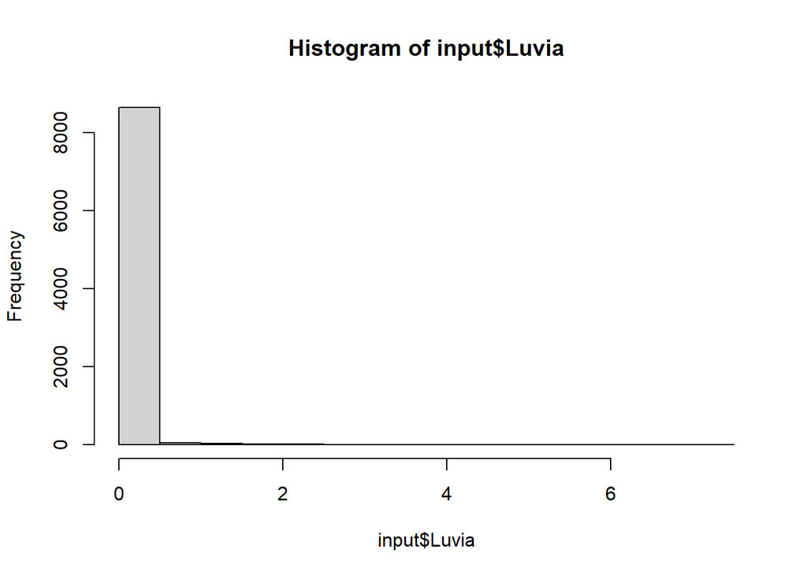

```r
hist(input$Luvia)
```

```r
#Revisando la distribución de los datos se consideró crear
#un variables para cuando no llueve y dos para cuando llueve

input$Luvia_bin<- (replace(input$Luvia, which(input$Luvia == 0), 0))
input$Luvia_bin<- (replace(input$Luvia_bin, which(input$Luvia_bin > 0 & input$Luvia_bin <= 1.1), 1))
input$Luvia_bin<- (replace(input$Luvia_bin, which(input$Luvia_bin > 1.1),2))

input$Luvia_bin<-as.factor(input$Luvia_bin)

levels(input$Luvia_bin)<-c('no_llueve','llueve','llueve_mas')

freq(input$Luvia_bin)
```

|  | n | % | val% |
| --- | --- | --- | --- |
| no_llueve | 8457 | 96.5 | 96.5 |
| llueve | 234 | 2.7 | 2.7 |
| llueve_mas | 69 | 0.8 | 0.8 |

```r
input<-subset(input, select =  -c(Luvia))
```

```r
# Distribuciones de numéricas
psych::describe(Filter(is.numeric, input)) #hay otro describe en otra libreria
```

|  | vars | n | mean | sd | median | trimmed | mad | min | max | range | skew | kurtosis | se |
| --- | --- | --- | --- | --- | --- | --- | --- | --- | --- | --- | --- | --- | --- |
| Radon | 1 | 8442 | 21.723940 | 18.430801 | 14.333333 | 18.35532 | 10.378200 | 0.0000000 | 148.6667 | 148.66667 | 1.72402472 | 3.0575833 | 0.20059566 |
| Desc.Rn | 2 | 7524 | 15.684868 | 17.371314 | 8.381667 | 12.02749 | 7.552611 | 0.1123333 | 115.3333 | 115.22100 | 2.02308478 | 4.1577087 | 0.20026649 |
| Pres | 3 | 8431 | 943.107507 | 5.685055 | 942.799833 | 942.92692 | 5.218999 | 925.5740000 | 961.9825 | 36.40850 | 0.32384073 | 0.4794043 | 0.06191489 |
| Temp | 4 | 8431 | 15.727543 | 9.826575 | 15.020000 | 15.43289 | 10.719198 | -7.4066667 | 41.2500 | 48.65667 | 0.23147911 | -0.6886711 | 0.10701943 |
| HR | 5 | 8431 | 55.084866 | 22.636232 | 54.233333 | 54.91443 | 27.872880 | 9.9000000 | 99.0000 | 89.10000 | 0.07343762 | -1.1014801 | 0.24652706 |
| Vviento | 6 | 8760 | 3.374608 | 3.547894 | 2.520000 | 2.82664 | 3.647196 | 0.0000000 | 53.4000 | 53.40000 | 1.54114619 | 6.0678995 | 0.03790692 |
| Irrad.solar | 7 | 7547 | 116.397293 | 154.686114 | 19.300000 | 88.27097 | 28.614180 | 0.0000000 | 570.8333 | 570.83333 | 1.22679448 | 0.1534562 | 1.78059092 |

```r
# % de atipicos por variable
sapply(Filter(is.numeric, input),function(x) atipicosAmissing(x)[[2]])/nrow(input)
```

```
##        Radon      Desc.Rn         Pres         Temp           HR      Vviento
## 0.0035388128 0.0196347032 0.0000000000 0.0000000000 0.0000000000 0.0001141553
##  Irrad.solar
## 0.0000000000
```

```r
# Modifico los atípicos como missings
input[,as.vector(which(sapply(input, class)=="numeric"))]<-sapply(Filter(is.numeric, input),function(x) atipicosAmissing(x)[[1]])

#Cuento ahora los registros con missings
sum(is.na(input))
```

```
## [1] 3958
```

Observamos que los porcentaje de atipicas por variables es poca, por lo cual no agrupamos categorias y reemplazamos por missings.

```r
# Ver el reparto de las categorìas de las variables cualitativas
lapply(Filter(is.factor,input),questionr::freq)
```

```
## $Luvia_bin
##               n    % val%
## no_llueve  8457 96.5 96.5
## llueve      234  2.7  2.7
## llueve_mas   69  0.8  0.8
```

Poca presencia de valores diferentes a ‘no_llueve’ pero podría haber un patrón cuando llueve

```r
# Missings no declarados variables cuantitativas (-1, 99999)
 input$Temp<-replace(input$Temp,which( input$Temp < 0),NA)
```

Imputacion a Misssings

Primero verificamos si hay patrones

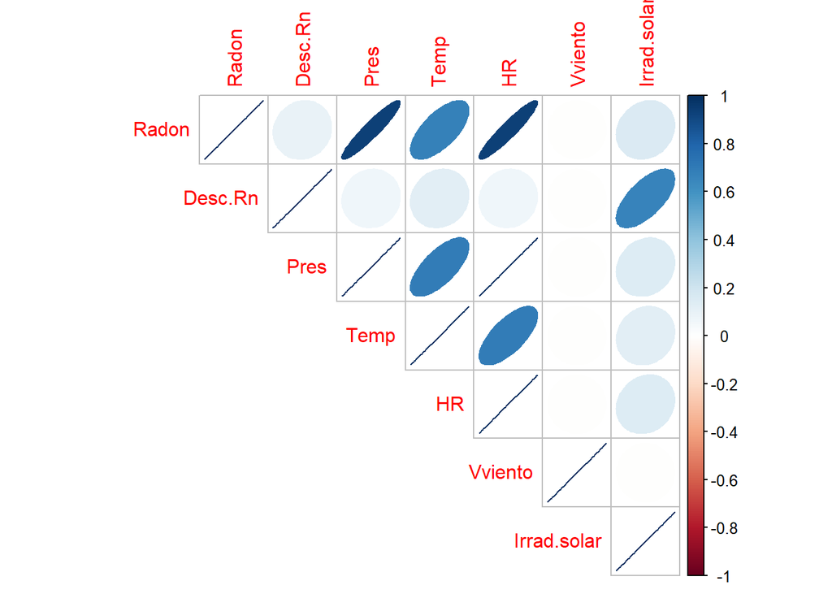

```r
## MISSINGS
# Patrones de missings
corrplot(cor(is.na(input[colnames(input)[colSums(is.na(input))>0]])),method = "ellipse",type = "upper")
```

```r
#is.na(input[colnames(input)[colSums(is.na(input))>0]])

#length(input$Irrad.solar[is.na(input$Irrad.solar)==TRUE])

#no funciona quitar misssings
# corrplot(cor( Filter(is.numeric,input)),method = "ellipse",type #= "upper")

# corrplot(cor(!is.na(Filter(is.numeric,input))),method = "ellipse",type = "upper")
```

Encontramos correlacion entre las variables:

Desc.Rn y Irrad.Solar Radon con Pres, Temp, HR

```r
#Proporción de missings por variable y observación
input$prop_missings<-apply(is.na(input),1,mean)

summary(input$prop_missings)
```

```
##    Min. 1st Qu.  Median    Mean 3rd Qu.    Max.
## 0.00000 0.00000 0.00000 0.05427 0.00000 0.66667
```

```r
prop_missingsVars<-apply(is.na(input),2,mean)

#Actualizar las observaciones de las variables objetivo

# length(varObjBin)#8760
# summary(varObjBin)
# which (is.na(varObjBin))
# length(which (is.na(varObjBin)) )#1146
varObjBin<-varObjBin[input$prop_missings<0.5]
# length(which (is.na(varObjBin[input$prop_missings<0.5])) )
# length(varObjBin)#8623
# length(which (is.na(varObjBin)) )#1146
varObjCont<-varObjCont[input$prop_missings<0.5]

#write.csv(input,"input.csv")

#elimino las observaciones y las variables con más de la mitad de missings
input <- subset(input, prop_missings< 0.5, select=names(prop_missingsVars)[prop_missingsVars<0.5])

#write.csv(input_0,"input_0.csv")

# input$prop_missings[input$prop_missings >= 0.5]
#
# write.csv(input$prop_missings < 0.5,"input_filtrado.csv")

#
# varObjBin<-varObjBin[input$prop_missings < 0.5]
# varObjBin<-varObjBin[input$prop_missings<0.5]
#
# class(varObjBin)
# class(varObjCont)
#
# length(varObjBin[input$prop_missings<0.5])
#
# length(varObjBin)
# length(varObjCont)
# nrow(input)



dim(na.omit(input))
```

```
## [1] 6665   10
```

```r
dim(input)
```

```
## [1] 8623   10
```

```r
#Separo una copia para aplicar otra tecnica de imputacion
#luego veremos para cada variable cual tecnica contribuye más
input_2<-input
```

```r
## Imputaciones
# Imputo todas las cuantitativas, seleccionar el tipo de #imputación: media, mediana o aleatorio

input[,as.vector(which(sapply(input, class)=="numeric"))]<-sapply(
  Filter(is.numeric, input),function(x) Hmisc::impute(x,"random"))


# Imputo todas las cualitativas, seleccionar el tipo de #imputación: moda o aleatorio
# Si solo se quiere imputar una,variable<-ImputacionCuali(variable,"moda")

input[,as.vector(which(sapply(input, class)=="factor"))]<-sapply(Filter(is.factor, input),function(x) ImputacionCuali(x,"aleatorio"))


# A veces se cambia el tipo de factor a character al imputar, así #que hay que indicarle que es factor

input[,as.vector(which(sapply(input, class)=="character"))] <- lapply(
  input[,as.vector(which(sapply(input, class)=="character"))] , factor)

# Reviso que no queden datos missings

summary(input)
```

```
##      Fecha                         Radon          Desc.Rn
##  Min.   :2005-01-01 00:00:58   Min.   : 0.00   Min.   : 0.1123
##  1st Qu.:2005-04-05 21:30:58   1st Qu.: 9.00   1st Qu.: 4.3183
##  Median :2005-07-04 17:00:58   Median :14.17   Median : 8.1833
##  Mean   :2005-07-03 20:20:13   Mean   :21.38   Mean   :14.2224
##  3rd Qu.:2005-10-03 03:30:58   3rd Qu.:28.33   3rd Qu.:18.7583
##  Max.   :2005-12-31 23:00:58   Max.   :96.83   Max.   :68.7500
##       Pres            Temp                HR           Vviento
##  Min.   :925.6   Min.   : 0.00167   Min.   : 9.90   Min.   : 0.00
##  1st Qu.:939.5   1st Qu.: 9.01667   1st Qu.:36.32   1st Qu.: 0.30
##  Median :942.8   Median :15.61667   Median :54.35   Median : 2.58
##  Mean   :943.1   Mean   :16.40486   Mean   :55.14   Mean   : 3.42
##  3rd Qu.:946.5   3rd Qu.:23.02000   3rd Qu.:74.08   3rd Qu.: 5.28
##  Max.   :962.0   Max.   :41.25000   Max.   :99.00   Max.   :29.64
##   Irrad.solar      Luvia_bin.Luvia_bin prop_missings
##  Min.   :  0.000   Length:8623         Min.   :0.00000
##  1st Qu.:  8.833   Class :character    1st Qu.:0.00000
##  Median : 19.167   Mode  :character    Median :0.00000
##  Mean   :116.324                       Mean   :0.04518
##  3rd Qu.:211.583                       3rd Qu.:0.00000
##  Max.   :570.833                       Max.   :0.44444
```

```r
any(is.na(input))
```

```
## [1] FALSE
```

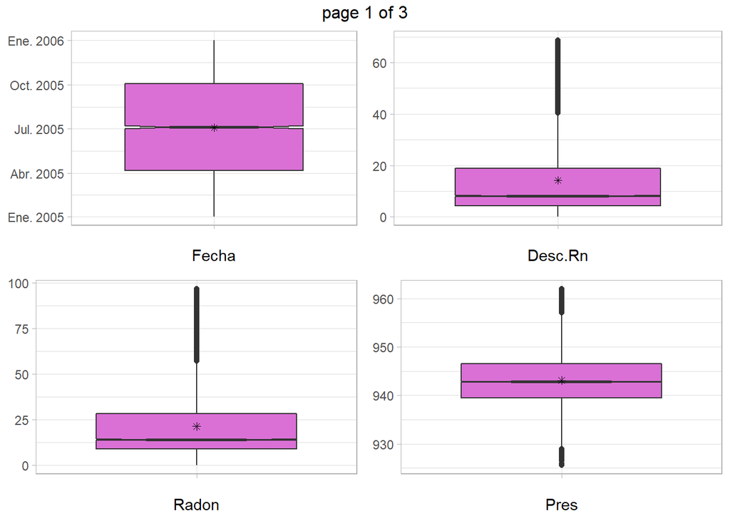

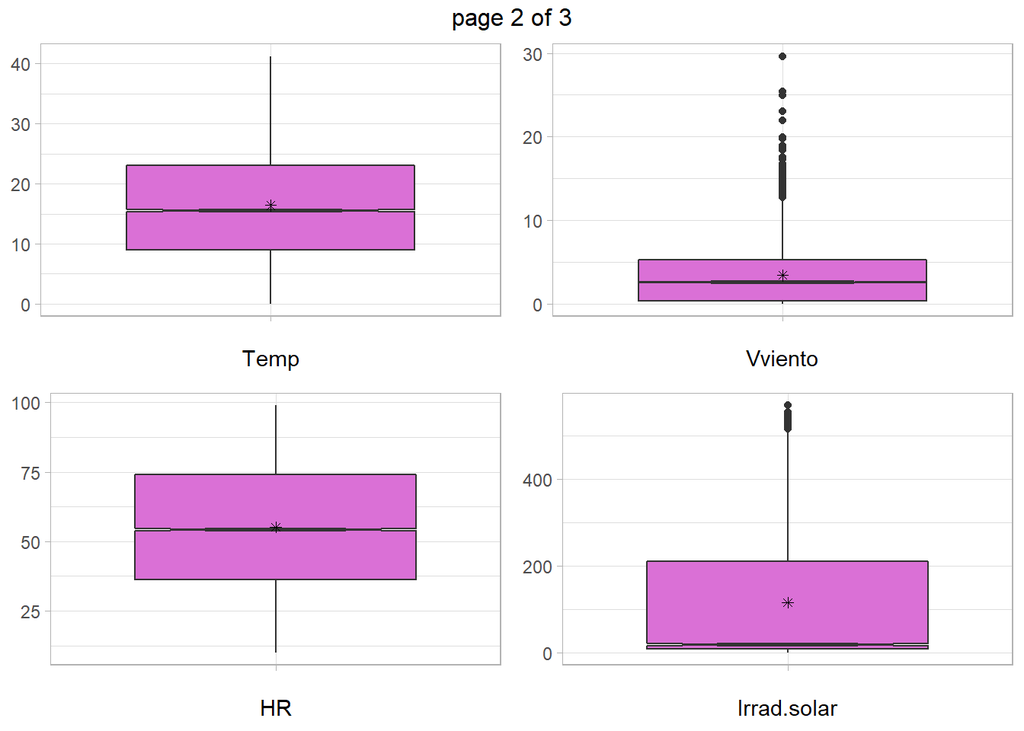

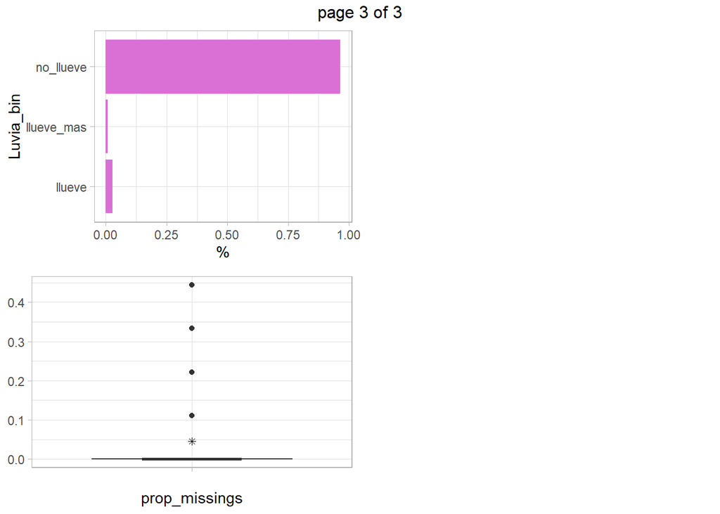

```r
# Es posible que quede algún missing sin imputar en variable #numéricas...algún pequeño fallo en la función. Pasaremos otra #vez el codigo para volver a imputar.

if (any(is.na(input))){
input[,as.vector(which(sapply(input, class)=="numeric"))]<-sapply(
  Filter(is.numeric, input),function(x) ImputacionCuant(x,"aleatorio"))
# Reviso que no queden datos missings
summary(input)
}

#Podemos graficar el dataset (opción 1 con boxplot para las #continuas)

input$Luvia_bin<-as.factor(input$Luvia_bin)

pl_box<-dfplot_box(input)

# Crear rejilla gráfica de 2x2
marrangeGrob(pl_box, nrow=2, ncol=2)
```

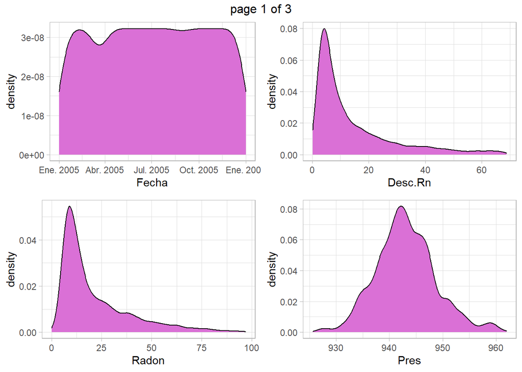

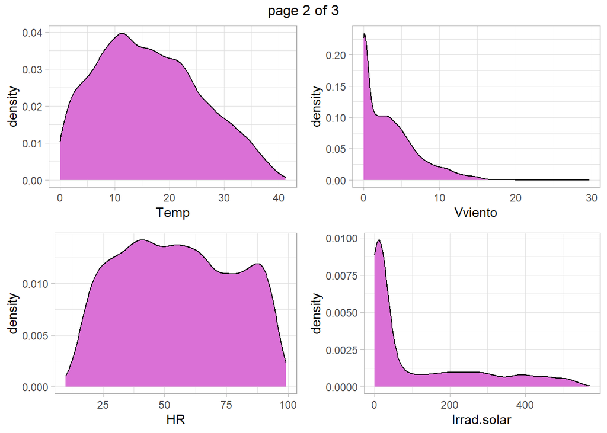

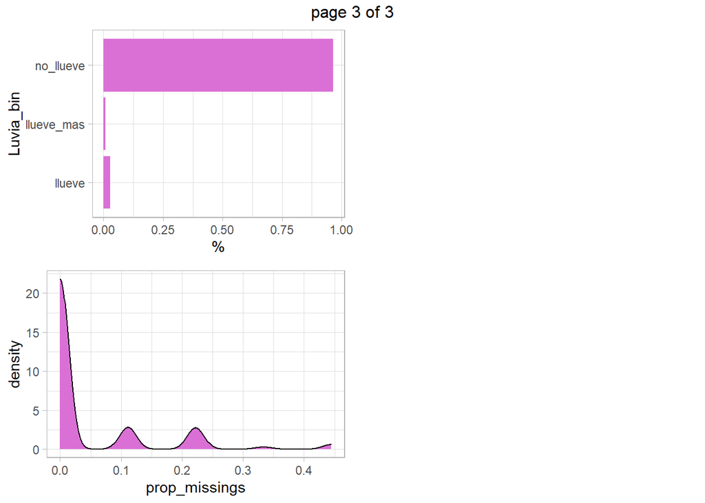

```r
#Podemos graficar el dataset (opción 2 con histograma para las #continuas)
pl_his<-dfplot_his(input)

# Crear rejilla gráfica de 2x2
marrangeGrob(pl_his, nrow=2, ncol=2)
```

```r
# sapply(input_2,class)
#
# sapply(Filter(is.numeric, input_2),function(x) length(unique(x)))

#sapply(input_2,function(x) sum(is.na(x)))


input_2_modif<- Hmisc::aregImpute(~ Radon + Desc.Rn + Pres + Temp + HR +
Vviento + Irrad.solar + Luvia_bin, data = input_2, n.impute = 5)
```

```
## Iteration 1
Iteration 2
Iteration 3
Iteration 4
Iteration 5
Iteration 6
Iteration 7
Iteration 8
```

```r
#apply(input_2_modif$imputed$Radon,1,mean)

input_2$Radon[which(is.na(input_2$Radon))]<-apply(input_2_modif$imputed$Radon,1,mean)

input_2$Desc.Rn[which(is.na(input_2$Desc.Rn))]<-apply(input_2_modif$imputed$Desc.Rn,1,mean)

input_2$Pres[which(is.na(input_2$Pres))]<-apply(input_2_modif$imputed$Pres,1,mean)

input_2$Temp[which(is.na(input_2$Temp))]<-apply(input_2_modif$imputed$Temp,1,mean)

input_2$HR[which(is.na(input_2$HR))]<-apply(input_2_modif$imputed$HR,1,mean)

input_2$Vviento[which(is.na(input_2$Vviento))]<-apply(input_2_modif$imputed$Vviento,1,mean)

input_2$Irrad.solar[which(is.na(input_2$Irrad.solar))]<-apply(input_2_modif$imputed$Irrad.solar,1,mean)
```

```r
input_2<-cbind(input_2$Radon,input_2$Desc.Rn,input_2$Pres,input_2$Temp,input_2$HR,input_2$Vviento,input_2$Irrad.solar)

colnames(input_2)<-c('Radon_2','Desc.Rn_2','Pres_2','Temp_2','HR_2',
                     'Vviento_2','Irrad.solar_2')
```

```r
# sapply(input_2,class)

#input<-readRDS("datosTarea")

#Realizaremos un tratamiento a la variables fecha

#Extrae mes
input$mes<-format(input$Fecha,"%m")

#Extrae dia
input$dia<-as.numeric(as.factor(format(input$Fecha,"%d")))

#Agrupamos cada 7 dias
input$semana_del_mes<-dplyr::case_when(
                      input$dia >= 1 & input$dia <=7     ~ "semana_1",
                      input$dia > 7 & input$dia <=14     ~ "semana_2",
                      input$dia > 14 & input$dia <=21     ~ "semana_3",                       input$dia > 21 & input$dia <=31     ~ "semana_4",
                      TRUE                     ~ "undetermined"
       )

#Quitamos el día, muchos valores para ser categórica
input<-subset(input, select =  -c(dia))


input$mes<-as.factor(input$mes)
input$semana_del_mes<-as.factor(input$semana_del_mes)

#unique(input$semana_del_mes)
```